# Explore Conflict Events in Africa from 1997 to 2018

CHEN Qingqing

March 01, 2018

# 1 Project Overview

In this project, I will use R and apply exploratory data analysis techniques to explore dataset of conflicts in Africa from 1997 to 2018, and the data is collected by the researchers at [ACLED](https://www.acleddata.com/).

# 2 Dataset Overview

```
## [1] 159515     28
```

```
##  [1] "ISO"              "EVENT_ID_CNTY"    "EVENT_ID_NO_CNTY"
##  [4] "EVENT_DATE"       "YEAR"             "TIME_PRECISION"
##  [7] "EVENT_TYPE"       "ACTOR1"           "ASSOC_ACTOR_1"
## [10] "INTER1"           "ACTOR2"           "ASSOC_ACTOR_2"
## [13] "INTER2"           "INTERACTION"      "REGION"
## [16] "COUNTRY"          "ADMIN1"           "ADMIN2"
## [19] "ADMIN3"           "LOCATION"         "LATITUDE"
## [22] "LONGITUDE"        "GEO_PRECISION"    "SOURCE"
## [25] "SOURCE_SCALE"     "NOTES"            "FATALITIES"
## [28] "TIMESTAMP"
```

```
## 'data.frame':    159515 obs. of  28 variables:
##  $ ISO             : num  12 12 12 12 12 12 12 12 12 12 ...
##  $ EVENT_ID_CNTY   : Factor w/ 159515 levels "4693.0","ALG1",..: 2 1113 2224 3335 4446 4715 4826 4937 5048 3 ...
##  $ EVENT_ID_NO_CNTY: num  1 2 3 4 5 6 7 8 9 10 ...
##  $ EVENT_DATE      : Factor w/ 7717 levels "1997-01-01 00:00:00",..: 1 2 3 4 5 6 6 7 7 7 ...
##  $ YEAR            : num  1997 1997 1997 1997 1997 ...
##  $ TIME_PRECISION  : num  1 1 1 1 1 1 1 1 1 1 ...
##  $ EVENT_TYPE      : Factor w/ 9 levels "Battle-Government regains territory",..: 9 9 9 9 9 2 9 6 6 2 ...
##  $ ACTOR1          : Factor w/ 3335 levels "\"Al Shabaab\" Militia",..: 849 849 849 849 849 2384 849 849 849 1685 ...
##  $ ASSOC_ACTOR_1   : Factor w/ 3252 levels "","\"Al Shabaab\" Militia",..: 1 1 1 1 1 1 1 1 1 1 ...
##  $ INTER1          : num  2 2 2 2 2 1 2 2 2 1 ...
##  $ ACTOR2          : Factor w/ 2874 levels "","\"Janjaweed\" Militia",..: 441 441 441 441 441 772 441 441 441 772 ...
##  $ ASSOC_ACTOR_2   : Factor w/ 2818 levels "","#FeesMustFall; Students (South Africa)",..: 1 1 1 1 1 1 1 1 1 1 ...
##  $ INTER2          : num  7 7 7 7 7 2 7 7 7 2 ...
##  $ INTERACTION     : num  27 27 27 27 27 12 27 27 27 12 ...
##  $ REGION          : Factor w/ 5 levels "Eastern Africa",..: 3 3 3 3 3 3 3 3 3 3 ...
##  $ COUNTRY         : Factor w/ 49 levels "Algeria","Angola",..: 1 1 1 1 1 1 1 1 1 1 ...
##  $ ADMIN1          : Factor w/ 754 levels "Abia","Abidjan",..: 694 594 25 91 694 25 694 576 25 694 ...
##  $ ADMIN2          : Factor w/ 4264 levels "","6th of October City",..: 1161 2651 3694 612 1161 937 1645 109 3694 1161 ...
##  $ ADMIN3          : Factor w/ 5016 levels "","3 De Fevereiro",..: 1 1 1 1 1 1 1 1 1 1 ...
##  $ LOCATION        : Factor w/ 18582 levels "10th of Ramadan City",..: 4836 6922 833 2533 4836 416 6787 429 833 4836 ...
##  $ LATITUDE        : num  36.7 36.1 36.8 36.5 36.7 ...
##  $ LONGITUDE       : num  2.789 0.883 3.042 2.829 2.789 ...
##  $ GEO_PRECISION   : num  1 1 3 1 1 1 1 1 1 1 ...
##  $ SOURCE          : Factor w/ 12509 levels ""," Agence France Presse",..: 12503 12503 12503 12503 12503 12503 12503 12503 12503 12503 ...
##  $ SOURCE_SCALE    : Factor w/ 32 levels "","International",..: 8 8 8 8 8 8 8 8 8 8 ...
##  $ NOTES           : Factor w/ 129317 levels ""," A farmer killed and a cattle-herder abducted by unknown gunmen on motorbikes in Woulango",..: 5964 115334 115337 5500 5965 5551 6426 48993 6696 42627 ...
##  $ FATALITIES      : num  5 2 2 16 18 4 23 7 20 0 ...
##  $ TIMESTAMP       : num  1.52e+09 1.52e+09 1.52e+09 1.52e+09 1.52e+09 ...
```

## 2.1 Overview

There are 159515 data with 28 variables in the dataset.

## 2.2 Variables Description:

- **EVENT_ID_CNTY**: An individual identifier by number and country acronym
- **EVENT_ID_NO_CNTY**: An individual numeric identifier
- **EVENT_DATE**: The day, month and year on which an event took place
- **YEAR**: The year in which an event took place
- **TIME_PRECISION**: A numeric code indicating the level of certainty of the date coded for the event
- **EVENT_TYPE**: The type of conflict event
- **ACTOR1**: The named actor involved in the event
- **ASSOC_ACTOR_1**:The named actor associated with or identifying ACTOR1
- **INTER1**: A numeric code indicating the type of ACTOR1
- **ACTOR2**: The named actor involved in the event
- **ASSOC_ACTOR_2**: The named actor allied with or identifying ACTOR2
- **INTER2**: A numeric code indicating the type of ACTOR2
- **INTERACTION**: A numeric code indicating the interaction between types of ACTOR1 and ACTOR2
- **REGION**: The region in which the event took place
- **COUNTRY**: The country in which the event took place
- **ADMIN1**: The largest sub-national administrative region in which the event took place
- **ADMIN2**: The second largest sub-national administrative region in which the event took place
- **ADMIN3**: The third largest sub-national administrative region in which the event took place
- **LOCATION**: The location in which the event took place
- **LATITUDE**: The latitude of the location
- **LONGITUDE**: The longitude of the location
- **GEO_PRECISION**: A numeric code indicating the level of certainty of the location coded for the event
- **SOURCE**: The source of the event report
- **NOTES**: A short description of the event
- **FATALITIES**: The number of reported fatalities which occurred during the event

## 2.3 Calculating Summary

### 2.3.1 Summary Fatalities by Region

```
##     Min.  1st Qu.   Median     Mean  3rd Qu.     Max.
##     0.00     0.00     0.00     4.53     1.00 25000.00
```

```
## df_new$REGION: Eastern Africa
##     Min.  1st Qu.   Median     Mean  3rd Qu.     Max.
##    0.000    0.000    0.000    4.558    1.000 1369.000
## --------------------------------------------------------
## df_new$REGION: Middle Africa
##     Min.  1st Qu.   Median     Mean  3rd Qu.     Max.
##     0.00     0.00     0.00    11.59     2.00 25000.00
## --------------------------------------------------------
## df_new$REGION: Northern Africa
##    Min. 1st Qu.  Median    Mean 3rd Qu.    Max.
##    0.00    0.00    0.00    3.57    1.00 1300.00
## --------------------------------------------------------
## df_new$REGION: Southern Africa
##    Min. 1st Qu.  Median    Mean 3rd Qu.    Max.
##  0.0000  0.0000  0.0000  0.1547  0.0000 34.0000
## --------------------------------------------------------
## df_new$REGION: Western Africa
##     Min.  1st Qu.   Median     Mean  3rd Qu.     Max.
##    0.000    0.000    0.000    3.036    1.000 1000.000
```

### 2.3.2 Summary Fatalities by Country

The details of fatalities in different can be found below:

```
##     Min.  1st Qu.   Median     Mean  3rd Qu.     Max.
##     0.00     0.00     0.00     4.53     1.00 25000.00
```

```
## df_new$COUNTRY: Algeria
##    Min. 1st Qu.  Median    Mean 3rd Qu.    Max.
##    0.00    0.00    0.00    2.65    2.00  321.00
## --------------------------------------------------------
## df_new$COUNTRY: Angola
##    Min. 1st Qu.  Median    Mean 3rd Qu.    Max.
##    0.00    0.00    0.00   45.32    2.00 5400.00
## --------------------------------------------------------
## df_new$COUNTRY: Benin
##    Min. 1st Qu.  Median    Mean 3rd Qu.    Max.
##  0.0000  0.0000  0.0000  0.3353  0.0000  8.0000
## --------------------------------------------------------
## df_new$COUNTRY: Botswana
##    Min. 1st Qu.  Median    Mean 3rd Qu.    Max.
## 0.00000 0.00000 0.00000 0.04444 0.00000 1.00000
## --------------------------------------------------------
## df_new$COUNTRY: Burkina Faso
##    Min. 1st Qu.  Median    Mean 3rd Qu.    Max.
##  0.0000  0.0000  0.0000  0.4863  0.0000 30.0000
## --------------------------------------------------------
## df_new$COUNTRY: Burundi
##    Min. 1st Qu.  Median    Mean 3rd Qu.    Max.
##   0.000   0.000   0.000   2.933   1.000 543.000
## --------------------------------------------------------
## df_new$COUNTRY: Cameroon
##    Min. 1st Qu.  Median    Mean 3rd Qu.    Max.
##   0.000   0.000   1.000   4.522   3.000 319.000
## --------------------------------------------------------
## df_new$COUNTRY: Central African Republic
##    Min. 1st Qu.  Median    Mean 3rd Qu.    Max.
##   0.000   0.000   0.000   3.231   2.000 200.000
## --------------------------------------------------------
## df_new$COUNTRY: Chad
##    Min. 1st Qu.  Median    Mean 3rd Qu.    Max.
##    0.00    0.00    0.00    9.64    3.00  400.00
## --------------------------------------------------------
## df_new$COUNTRY: Democratic Republic of Congo
##      Min.   1st Qu.    Median      Mean   3rd Qu.      Max.
##     0.000     0.000     0.000     6.594     1.000 25000.000
## --------------------------------------------------------
```

[output cut: 140 more lines]

```
## df_new$COUNTRY: Tunisia
##    Min. 1st Qu.  Median    Mean 3rd Qu.    Max.
##  0.0000  0.0000  0.0000  0.2004  0.0000 54.0000
## --------------------------------------------------------
## df_new$COUNTRY: Uganda
##    Min. 1st Qu.  Median    Mean 3rd Qu.    Max.
##   0.000   0.000   0.000   3.026   2.000 530.000
## --------------------------------------------------------
## df_new$COUNTRY: Zambia
##    Min. 1st Qu.  Median    Mean 3rd Qu.    Max.
##   0.000   0.000   0.000   0.211   0.000  12.000
## --------------------------------------------------------
## df_new$COUNTRY: Zimbabwe
##     Min.  1st Qu.   Median     Mean  3rd Qu.     Max.
##  0.00000  0.00000  0.00000  0.07187  0.00000 13.00000
```

### 2.3.3 Summary Conflict Event Type by Region

- There are totally 9 types of conflict event which are “Battle-Government regains territory,Battle-Non-state actor overtakes territory, Non-violent transfer of territory, Riots/Protests, Violence against civilians, Battle-No change of territory, Headquarters or base established, Remote violence, Strategic development”.
- The mostly happened conflict event is ‘Violence against civilians’ and the seldom happened conflict is ‘Headquarters or base established’.
- The frequency of different conflict event happeded in different regions is shown below:

```
##        Battle-Government regains territory
##                                       2439
##              Battle-No change of territory
##                                      43425
## Battle-Non-state actor overtakes territory
##                                       2128
##           Headquarters or base established
##                                        760
##          Non-violent transfer of territory
##                                       2496
##                            Remote violence
##                                      10111
##                             Riots/Protests
##                                      42070
##                      Strategic development
##                                      11488
##                 Violence against civilians
##                                      44593
```

```
## df_new$REGION: Eastern Africa
##        Battle-Government regains territory
##                                        495
##              Battle-No change of territory
##                                      20871
## Battle-Non-state actor overtakes territory
##                                        466
##           Headquarters or base established
##                                        145
##          Non-violent transfer of territory
##                                        587
##                            Remote violence
##                                       4143
##                             Riots/Protests
##                                       8585
##                      Strategic development
##                                       4522
##                 Violence against civilians
##                                      17137
## --------------------------------------------------------
## df_new$REGION: Middle Africa
##        Battle-Government regains territory
##                                        951
##              Battle-No change of territory
##                                       7941
## Battle-Non-state actor overtakes territory
##                                        614
##           Headquarters or base established
##                                        114
##          Non-violent transfer of territory
##                                        486
##                            Remote violence
##                                        330
##                             Riots/Protests
##                                       2340
##                      Strategic development
##                                       1791
##                 Violence against civilians
##                                       6768
## --------------------------------------------------------
```

[output cut: 44 more lines]

```
##                                       5932
## Battle-Non-state actor overtakes territory
##                                        533
##           Headquarters or base established
##                                        339
##          Non-violent transfer of territory
##                                       1317
##                            Remote violence
##                                        909
##                             Riots/Protests
##                                       7910
##                      Strategic development
##                                       2046
##                 Violence against civilians
##                                       7243
```

### 2.3.4 Summary Conflict Event Type by Country

The details of conflict event type happeded in different can be found below:

```
## df_new$COUNTRY: Algeria
##        Battle-Government regains territory
##                                         19
##              Battle-No change of territory
##                                       1560
## Battle-Non-state actor overtakes territory
##                                          1
##           Headquarters or base established
##                                          2
##          Non-violent transfer of territory
##                                          1
##                            Remote violence
##                                        578
##                             Riots/Protests
##                                       2047
##                      Strategic development
##                                        330
##                 Violence against civilians
##                                        618
## --------------------------------------------------------
## df_new$COUNTRY: Angola
##        Battle-Government regains territory
##                                        243
##              Battle-No change of territory
##                                       1913
## Battle-Non-state actor overtakes territory
##                                         11
##           Headquarters or base established
##                                          2
##          Non-violent transfer of territory
##                                        137
##                            Remote violence
##                                         77
##                             Riots/Protests
##                                        179
##                      Strategic development
##                                         49
##                 Violence against civilians
##                                        562
## --------------------------------------------------------
```

[output cut: 924 more lines]

```
##                                         86
## Battle-Non-state actor overtakes territory
##                                          0
##           Headquarters or base established
##                                        126
##          Non-violent transfer of territory
##                                          3
##                            Remote violence
##                                         15
##                             Riots/Protests
##                                       1054
##                      Strategic development
##                                        366
##                 Violence against civilians
##                                       4166
```

### 2.3.5 Other variables summary

```
## $TIME_PRECISION
##    Min. 1st Qu.  Median    Mean 3rd Qu.    Max.
##   1.000   1.000   1.000   1.142   1.000   3.000
##
## $INTER1
##    Min. 1st Qu.  Median    Mean 3rd Qu.    Max.
##   1.000   1.000   3.000   3.339   5.000   8.000
##
## $INTER2
##    Min. 1st Qu.  Median    Mean 3rd Qu.    Max.
##   0.000   1.000   2.000   3.273   7.000   8.000
##
## $INTERACTION
##    Min. 1st Qu.  Median    Mean 3rd Qu.    Max.
##   10.00   14.00   28.00   31.53   47.00   88.00
##
## $LATITUDE
##    Min. 1st Qu.  Median    Mean 3rd Qu.    Max.
## -34.710  -1.283   4.861   5.577  12.000  37.274
##
## $LONGITUDE
##    Min. 1st Qu.  Median    Mean 3rd Qu.    Max.
##  -17.46   13.58   29.29   24.53   34.13   51.27
##
## $GEO_PRECISION
##    Min. 1st Qu.  Median    Mean 3rd Qu.    Max.
##   1.000   1.000   1.000   1.264   1.000   3.000
##
## $year
##    Min. 1st Qu.  Median    Mean 3rd Qu.    Max.
##    1997    2007    2013    2011    2015    2018
##
## $month
##    Min. 1st Qu.  Median    Mean 3rd Qu.    Max.
##   1.000   3.000   6.000   6.316   9.000  12.000
##
## $day
##    Min. 1st Qu.  Median    Mean 3rd Qu.    Max.
##    1.00    8.00   15.00   15.43   23.00   31.00
```

# 3 Univariate Plots Section

## 3.1 Conflict Event Type Bar Plot

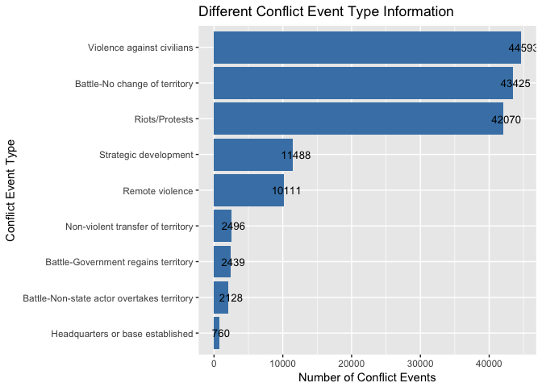

- The top three common type of conflict event are **“Violence against civilians (44593), Battle-No change of territory (43425), Riots/Protests (42070)”**, separately.
- The most unusual type of conflict event is ‘Headquarters or base established’.
- Both common type and most unusual type of conflict event all can make further discussion.

## 3.2 Conflict Event Type Pie Chart

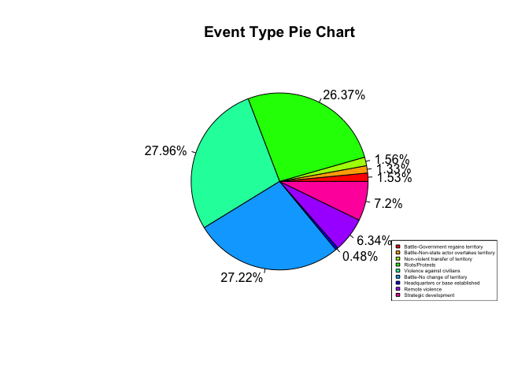

- The percentage of top three common conflict event type (“Violence against civilians, Battle-No change of territory, Riots/Protests”) are 27.96%, 27.22% and 26.37%

# 4 Bivariate Plots Section

## 4.1 Conflict Event Type by Region

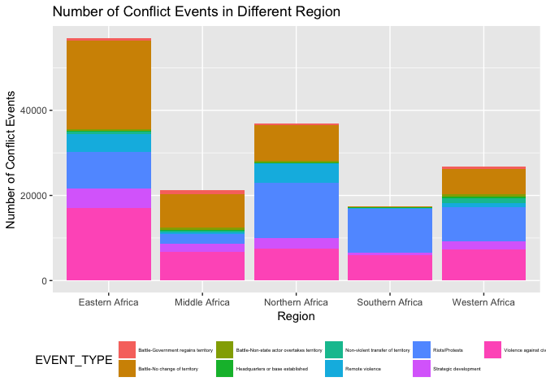

- The highest number of conflict events appeared in **Eastern Africa** and the lowest number of conflict events appeared in **Southern Africa**
- We can further look into the data in Eastern Afirca uncover more insights

## 4.2 Conflict Event Type by Country

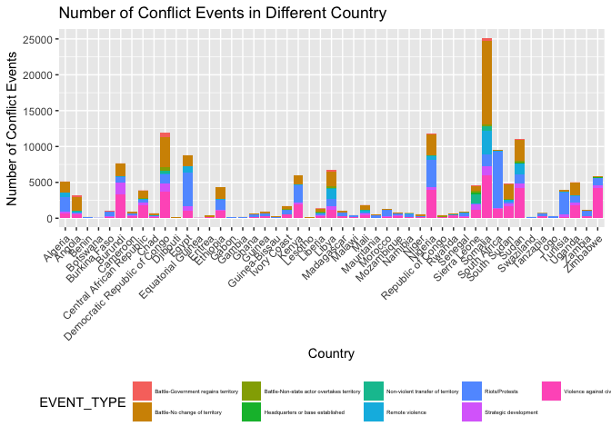

- Somalia has the highest number of conflict events, and followed by Democratic Republic of Congo, Nigeria and Sudan.
- We can pay a bit more attention to these countries where the conflict appeared quite ofen.

## 4.3 Conflict Event Type by Year

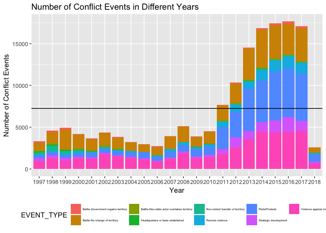

- We can see clearly from the ploted figure above that: - The number of conflict events happened before 2011 is relatively low (lower than the aveage) and it shows a significant increasement in 2011 (higher than the average). - The number of conflict events happened in 2013, 2014, 2015, 2016 and 2017 is quite high, where 2016 reached the highest point. (2018 data only updated to Feb) - We can focuse more on years 2013, 2014, 2015, 2016 and 2017.

## 4.4 Conflict Event Type by Month

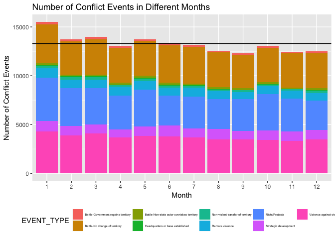

- Conflict events a bit more likely happened in January compared to the rest months of the year.

```r
summary(df_new$FATALITIES)
```

```
##     Min.  1st Qu.   Median     Mean  3rd Qu.     Max.
##     0.00     0.00     0.00     4.53     1.00 25000.00
```

## 4.5 Fatalities Barplot

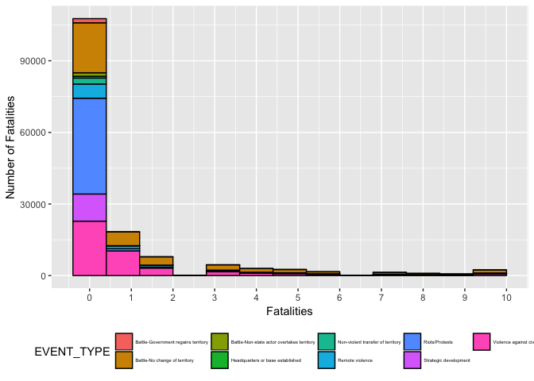

- Mostly there is small number of fatalited in events, so in order to have a clearer plot, I limited the fatalities number within 10 people.

## 4.6 Interaction Barplot

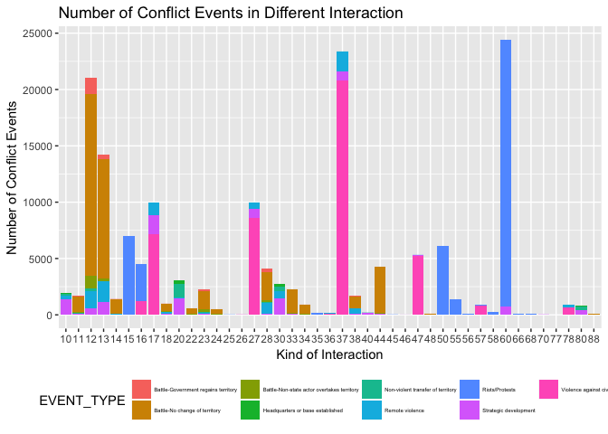

- The first three interaction is 60, 37 and 12 which corresponded to “Sole Protester Action”, “Political Militia Versus Civilians” and “Military Versus Rebels” according to ACLED codebook;
- We can link this to the Actor factors for further exploratory.

# 5 Multivariate Plots Section

## 5.1 Conflict Event Type in different years groupby Region

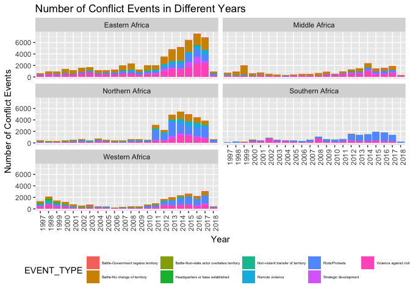

## 5.2 Event Type VS. Fatalities

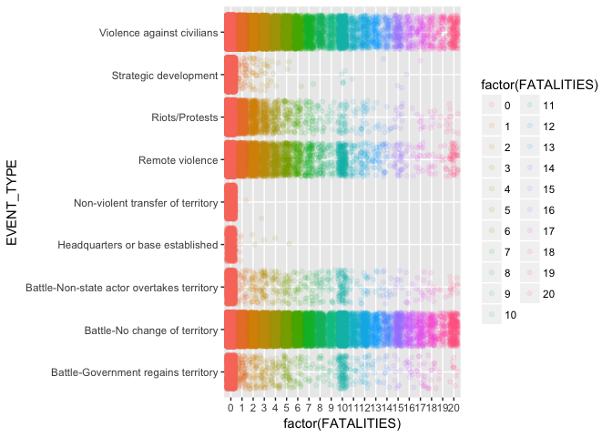

## 5.3 Event Type VS. Fatalities groupby Region

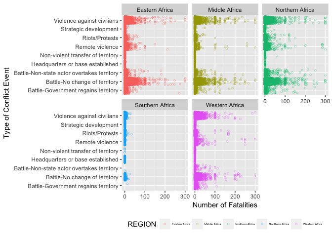

```r
p10 <- ggplot(aes(y=EVENT_TYPE,x=FATALITIES),data = subset(df_new, df_new$FATALITIES <= 300)) +
  geom_jitter(aes(color = REGION),alpha=1/3,pch=21,cex=1)+
  facet_wrap(~REGION)+
  theme(legend.position="bottom", legend.text=element_text(size=rel(0.4))) +
  labs(y = "Type of Conflict Event",
    x = "Number of Fatalities")
p10
```

- “Violence against civilians, Riots/Protests, Remote violence and Battle-No change of territory” type of conflict events caused more fatalites

## 5.4 Fatalities counts groupby regions

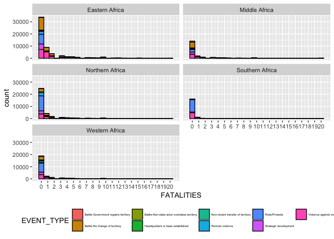

- Eastern Africa has more conflict events
- The number of fatilities of each event is small in all regions, mostly is within 5 people.

## 5.5 Fatalities counts groupby years

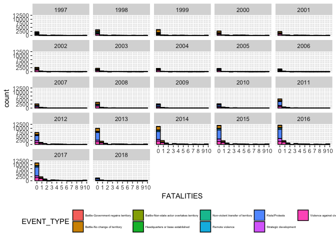